# Employee Attrition Analysis through Machine Learning

**Submitted By:** Thushar J K

**Roll Number:** 242626040

**Date:** August 30, 2025

- Problem Statement
- Section 1: Importing Libraries and Loading the Dataset
- Section 2: Exploratory Data Analysis (EDA) - Understanding Attrition
- Section 3: EDA - Numerical Features
- Section 4: EDA - Categorical and Ordinal Features
- Section 5: Data Preprocessing
- Section 6: Model Training and Evaluation
- Section 7: Hyperparameter Tuning
- Section 8: Feature Importance

## Problem Statement

Employee attrition refers to the phenomenon where employees voluntarily leave an organization, which can pose significant challenges for businesses. It often results in the loss of valuable institutional knowledge, increased recruitment and training costs, and potential disruptions to team productivity and morale. In this guide, we will explore a dataset containing information about employees to uncover patterns and factors that contribute to attrition. Our primary objective is to build a machine learning model that can predict whether an employee is likely to leave based on various attributes such as age, income, job satisfaction, and work environment. This task falls under binary classification in machine learning, where the model learns to categorize outcomes into two classes: "Yes" for attrition or "No" for retention.

The dataset we are using is from the file "WA_Fn-UseC_-HR-Employee-Attrition.csv," which includes 1470 records of employees with 35 features. These features encompass numerical data like age and monthly income, as well as categorical data like department and overtime status. The target variable is "Attrition," indicating whether the employee left ("Yes") or stayed ("No").

## Section 1: Importing Libraries and Loading the Dataset

```python
import pandas as pd
import matplotlib.pyplot as plt
import seaborn as sns

df = pd.read_csv("WA_Fn-UseC_-HR-Employee-Attrition.csv")
df.head()
```

|  | Age | Attrition | BusinessTravel | DailyRate | Department | DistanceFromHome | Education | EducationField | EmployeeCount | EmployeeNumber | ... | RelationshipSatisfaction | StandardHours | StockOptionLevel | TotalWorkingYears | TrainingTimesLastYear | WorkLifeBalance | YearsAtCompany | YearsInCurrentRole | YearsSinceLastPromotion | YearsWithCurrManager |
| --- | --- | --- | --- | --- | --- | --- | --- | --- | --- | --- | --- | --- | --- | --- | --- | --- | --- | --- | --- | --- | --- |
| 0 | 41 | Yes | Travel_Rarely | 1102 | Sales | 1 | 2 | Life Sciences | 1 | 1 | ... | 1 | 80 | 0 | 8 | 0 | 1 | 6 | 4 | 0 | 5 |
| 1 | 49 | No | Travel_Frequently | 279 | Research & Development | 8 | 1 | Life Sciences | 1 | 2 | ... | 4 | 80 | 1 | 10 | 3 | 3 | 10 | 7 | 1 | 7 |
| 2 | 37 | Yes | Travel_Rarely | 1373 | Research & Development | 2 | 2 | Other | 1 | 4 | ... | 2 | 80 | 0 | 7 | 3 | 3 | 0 | 0 | 0 | 0 |
| 3 | 33 | No | Travel_Frequently | 1392 | Research & Development | 3 | 4 | Life Sciences | 1 | 5 | ... | 3 | 80 | 0 | 8 | 3 | 3 | 8 | 7 | 3 | 0 |
| 4 | 27 | No | Travel_Rarely | 591 | Research & Development | 2 | 1 | Medical | 1 | 7 | ... | 4 | 80 | 1 | 6 | 3 | 3 | 2 | 2 | 2 | 2 |

5 rows × 35 columns

This gives a quick snapshot of the data's format.

```python
df.info()
```

```
<class 'pandas.core.frame.DataFrame'>
RangeIndex: 1470 entries, 0 to 1469
Data columns (total 35 columns):
 #   Column                    Non-Null Count  Dtype
---  ------                    --------------  -----
 0   Age                       1470 non-null   int64
 1   Attrition                 1470 non-null   object
 2   BusinessTravel            1470 non-null   object
 3   DailyRate                 1470 non-null   int64
 4   Department                1470 non-null   object
 5   DistanceFromHome          1470 non-null   int64
 6   Education                 1470 non-null   int64
 7   EducationField            1470 non-null   object
 8   EmployeeCount             1470 non-null   int64
 9   EmployeeNumber            1470 non-null   int64
```

[output cut: 27 more lines]

This command reveals that there are 1470 entries across 35 columns, with 26 numerical (integer) columns and 9 object (text) columns. Importantly, there are no missing values, which simplifies our preprocessing.

```python
df.describe()
```

|  | Age | DailyRate | DistanceFromHome | Education | EmployeeCount | EmployeeNumber | EnvironmentSatisfaction | HourlyRate | JobInvolvement | JobLevel | ... | RelationshipSatisfaction | StandardHours | StockOptionLevel | TotalWorkingYears | TrainingTimesLastYear | WorkLifeBalance | YearsAtCompany | YearsInCurrentRole | YearsSinceLastPromotion | YearsWithCurrManager |
| --- | --- | --- | --- | --- | --- | --- | --- | --- | --- | --- | --- | --- | --- | --- | --- | --- | --- | --- | --- | --- | --- |
| count | 1470.000000 | 1470.000000 | 1470.000000 | 1470.000000 | 1470.0 | 1470.000000 | 1470.000000 | 1470.000000 | 1470.000000 | 1470.000000 | ... | 1470.000000 | 1470.0 | 1470.000000 | 1470.000000 | 1470.000000 | 1470.000000 | 1470.000000 | 1470.000000 | 1470.000000 | 1470.000000 |
| mean | 36.923810 | 802.485714 | 9.192517 | 2.912925 | 1.0 | 1024.865306 | 2.721769 | 65.891156 | 2.729932 | 2.063946 | ... | 2.712245 | 80.0 | 0.793878 | 11.279592 | 2.799320 | 2.761224 | 7.008163 | 4.229252 | 2.187755 | 4.123129 |
| std | 9.135373 | 403.509100 | 8.106864 | 1.024165 | 0.0 | 602.024335 | 1.093082 | 20.329428 | 0.711561 | 1.106940 | ... | 1.081209 | 0.0 | 0.852077 | 7.780782 | 1.289271 | 0.706476 | 6.126525 | 3.623137 | 3.222430 | 3.568136 |
| min | 18.000000 | 102.000000 | 1.000000 | 1.000000 | 1.0 | 1.000000 | 1.000000 | 30.000000 | 1.000000 | 1.000000 | ... | 1.000000 | 80.0 | 0.000000 | 0.000000 | 0.000000 | 1.000000 | 0.000000 | 0.000000 | 0.000000 | 0.000000 |
| 25% | 30.000000 | 465.000000 | 2.000000 | 2.000000 | 1.0 | 491.250000 | 2.000000 | 48.000000 | 2.000000 | 1.000000 | ... | 2.000000 | 80.0 | 0.000000 | 6.000000 | 2.000000 | 2.000000 | 3.000000 | 2.000000 | 0.000000 | 2.000000 |
| 50% | 36.000000 | 802.000000 | 7.000000 | 3.000000 | 1.0 | 1020.500000 | 3.000000 | 66.000000 | 3.000000 | 2.000000 | ... | 3.000000 | 80.0 | 1.000000 | 10.000000 | 3.000000 | 3.000000 | 5.000000 | 3.000000 | 1.000000 | 3.000000 |
| 75% | 43.000000 | 1157.000000 | 14.000000 | 4.000000 | 1.0 | 1555.750000 | 4.000000 | 83.750000 | 3.000000 | 3.000000 | ... | 4.000000 | 80.0 | 1.000000 | 15.000000 | 3.000000 | 3.000000 | 9.000000 | 7.000000 | 3.000000 | 7.000000 |
| max | 60.000000 | 1499.000000 | 29.000000 | 5.000000 | 1.0 | 2068.000000 | 4.000000 | 100.000000 | 4.000000 | 5.000000 | ... | 4.000000 | 80.0 | 3.000000 | 40.000000 | 6.000000 | 4.000000 | 40.000000 | 18.000000 | 15.000000 | 17.000000 |

8 rows × 26 columns

The summary statistics table indicates, for instance, that the average age is about 37 years, with a range from 18 to 60. Monthly income averages around 6503, but varies widely from 1009 to 19999. Columns like EmployeeCount and StandardHours are constant (always 1 and 80, respectively), meaning they won't help in predictions and can be dropped later.

From this initial inspection, the dataset appears clean and ready for exploration. The absence of missing values is a relief, but the presence of constant columns reminds us to clean unnecessary features to focus the model on meaningful data.

## Section 2: Exploratory Data Analysis (EDA) - Understanding Attrition

We calculate the percentage of "Yes" and "No" in Attrition and visualize it with a bar chart for clarity.

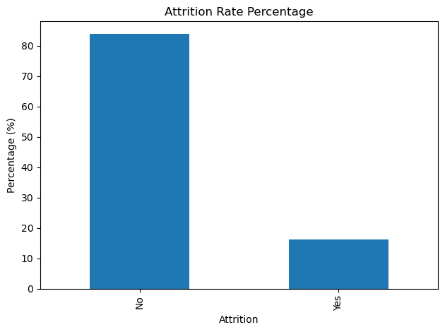

```python
attrition_percent = df['Attrition'].value_counts(normalize=True) * 100
attrition_percent.plot(kind='bar')
plt.title('Attrition Rate Percentage')
plt.xlabel('Attrition')
plt.ylabel('Percentage (%)')
plt.tight_layout()
plt.show()
```

The bar chart shows approximately 84% "No" and 16% "Yes," confirming the imbalance. This means our models need strategies like class weighting to avoid ignoring the minority class. In practice, this imbalance reflects real-world scenarios where most employees stay, but predicting the few who leave is crucial for retention efforts.

Employee attrition at IBM is relatively low, with most employees choosing to stay with the company.

## Section 3: EDA - Numerical Features

Numerical features are continuous or discrete numbers, such as age or salary. Analyzing them helps identify distributions, correlations, and how they differ between attrition groups. For example, we might find that younger employees or those with longer commutes are more likely to leave.

First, we select numerical columns and examine their statistics and distributions.

```python
num_cols = df.select_dtypes(include=['number']).columns
df[num_cols].describe().T
```

|  | count | mean | std | min | 25% | 50% | 75% | max |
| --- | --- | --- | --- | --- | --- | --- | --- | --- |
| Age | 1470.0 | 36.923810 | 9.135373 | 18.0 | 30.00 | 36.0 | 43.00 | 60.0 |
| DailyRate | 1470.0 | 802.485714 | 403.509100 | 102.0 | 465.00 | 802.0 | 1157.00 | 1499.0 |
| DistanceFromHome | 1470.0 | 9.192517 | 8.106864 | 1.0 | 2.00 | 7.0 | 14.00 | 29.0 |
| Education | 1470.0 | 2.912925 | 1.024165 | 1.0 | 2.00 | 3.0 | 4.00 | 5.0 |
| EmployeeCount | 1470.0 | 1.000000 | 0.000000 | 1.0 | 1.00 | 1.0 | 1.00 | 1.0 |
| EmployeeNumber | 1470.0 | 1024.865306 | 602.024335 | 1.0 | 491.25 | 1020.5 | 1555.75 | 2068.0 |
| EnvironmentSatisfaction | 1470.0 | 2.721769 | 1.093082 | 1.0 | 2.00 | 3.0 | 4.00 | 4.0 |
| HourlyRate | 1470.0 | 65.891156 | 20.329428 | 30.0 | 48.00 | 66.0 | 83.75 | 100.0 |
| JobInvolvement | 1470.0 | 2.729932 | 0.711561 | 1.0 | 2.00 | 3.0 | 3.00 | 4.0 |
| JobLevel | 1470.0 | 2.063946 | 1.106940 | 1.0 | 1.00 | 2.0 | 3.00 | 5.0 |
| JobSatisfaction | 1470.0 | 2.728571 | 1.102846 | 1.0 | 2.00 | 3.0 | 4.00 | 4.0 |
| MonthlyIncome | 1470.0 | 6502.931293 | 4707.956783 | 1009.0 | 2911.00 | 4919.0 | 8379.00 | 19999.0 |
| MonthlyRate | 1470.0 | 14313.103401 | 7117.786044 | 2094.0 | 8047.00 | 14235.5 | 20461.50 | 26999.0 |
| NumCompaniesWorked | 1470.0 | 2.693197 | 2.498009 | 0.0 | 1.00 | 2.0 | 4.00 | 9.0 |
| PercentSalaryHike | 1470.0 | 15.209524 | 3.659938 | 11.0 | 12.00 | 14.0 | 18.00 | 25.0 |
| PerformanceRating | 1470.0 | 3.153741 | 0.360824 | 3.0 | 3.00 | 3.0 | 3.00 | 4.0 |
| RelationshipSatisfaction | 1470.0 | 2.712245 | 1.081209 | 1.0 | 2.00 | 3.0 | 4.00 | 4.0 |
| StandardHours | 1470.0 | 80.000000 | 0.000000 | 80.0 | 80.00 | 80.0 | 80.00 | 80.0 |
| StockOptionLevel | 1470.0 | 0.793878 | 0.852077 | 0.0 | 0.00 | 1.0 | 1.00 | 3.0 |
| TotalWorkingYears | 1470.0 | 11.279592 | 7.780782 | 0.0 | 6.00 | 10.0 | 15.00 | 40.0 |
| TrainingTimesLastYear | 1470.0 | 2.799320 | 1.289271 | 0.0 | 2.00 | 3.0 | 3.00 | 6.0 |
| WorkLifeBalance | 1470.0 | 2.761224 | 0.706476 | 1.0 | 2.00 | 3.0 | 3.00 | 4.0 |
| YearsAtCompany | 1470.0 | 7.008163 | 6.126525 | 0.0 | 3.00 | 5.0 | 9.00 | 40.0 |
| YearsInCurrentRole | 1470.0 | 4.229252 | 3.623137 | 0.0 | 2.00 | 3.0 | 7.00 | 18.0 |
| YearsSinceLastPromotion | 1470.0 | 2.187755 | 3.222430 | 0.0 | 0.00 | 1.0 | 3.00 | 15.0 |
| YearsWithCurrManager | 1470.0 | 4.123129 | 3.568136 | 0.0 | 2.00 | 3.0 | 7.00 | 17.0 |

The list includes features like Age and DailyRate, and the transposed description shows details like means and ranges, highlighting variations (e.g., DistanceFromHome up to 29).

We can see both Employee Count and Standard Hours have constant mean, standard deviation, quartiles and range values across all departments. This indicates that these two variables are having same values for employees.

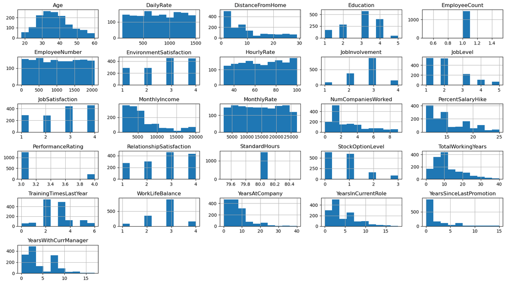

```python
df[num_cols].hist(figsize=(16,9))
plt.tight_layout()
plt.show()
```

The histograms reveal shapes: Age is somewhat normally distributed but skewed toward younger ages, while features like YearsAtCompany are right-skewed with many low values, indicating many short-tenured employees.

Next, we check correlations to spot multicollinearity, where highly related features can redundant or confuse models.

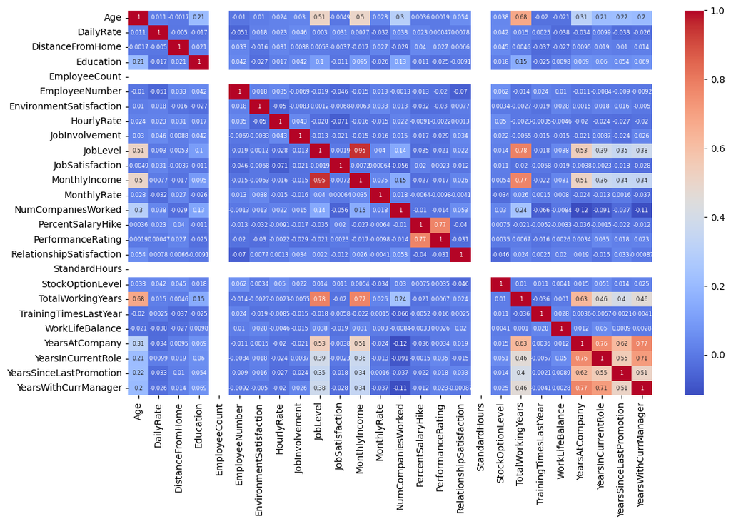

```python
plt.figure(figsize=(12,8))
sns.heatmap(df[num_cols].corr(), annot=True, cmap='coolwarm', annot_kws={'fontsize': 6})
plt.tight_layout()
plt.show()
```

The heatmap displays correlations from -1 to 1, with warm colors for positive links. Notable high correlations include JobLevel and MonthlyIncome (around 0.95), suggesting they measure similar things—career advancement and pay. Such multicollinearity might require dropping one feature to improve model stability.

Finally, boxplots compare numerical features across Attrition groups.

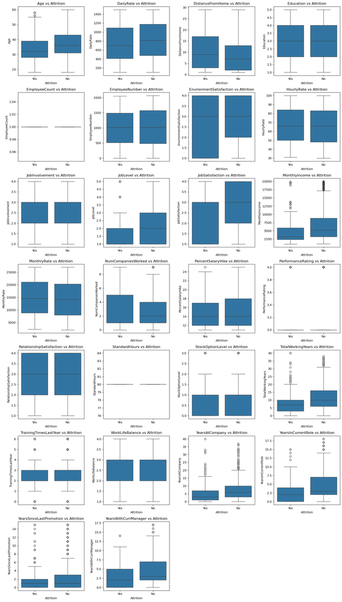

```python
num_plots = len(num_cols)
cols = 4
rows = (num_plots // cols) + int(num_plots % cols > 0)
fig, axes = plt.subplots(rows, cols, figsize=(cols*4, rows*4))
axes = axes.flatten()

for i, col in enumerate(num_cols):
    sns.boxplot(x='Attrition', y=col, data=df, ax=axes[i])
    axes[i].set_title(f'{col} vs Attrition')

for j in range(i+1, len(axes)):
    axes[j].axis('off')

plt.tight_layout()
plt.show()
```

These boxplots show medians and spreads; for example, the "Yes" group has lower median Age, MonthlyIncome, and YearsAtCompany, implying that younger, less paid, and shorter-tenured employees are more prone to attrition. This visual comparison aids in interpreting which factors might drive leaving.

Factors linked to higher attrition:

- Younger age
- Greater distance from home
- Lower environment satisfaction
- Lower job level
- Lower job satisfaction
- Lower monthly income
- More companies worked at
- Fewer total working years
- Fewer years at the company
- Fewer years in current role
- More likely to leave sooner after promotion

Factors with no clear link to attrition:

- Education
- Daily rate
- Hourly rate
- Job involvement
- Monthly rate
- Percent salary hike
- Performance rating
- Relationship satisfaction
- Standard hours
- Stock option level
- Work life balance
- Training times last year

Overall, numerical EDA uncovers skewed distributions that may benefit from transformations, potential multicollinearity to address, and clear differences in features between attrition groups, guiding feature selection.

## Section 4: EDA - Categorical and Ordinal Features

Categorical features are non-numerical, like department or gender, while ordinal ones have inherent order, such as satisfaction levels from 1 to 4. Exploring these helps reveal if certain categories or levels are associated with higher attrition rates, providing interpretable insights like "overtime workers leave more."

We start with categorical distributions and their relation to attrition.

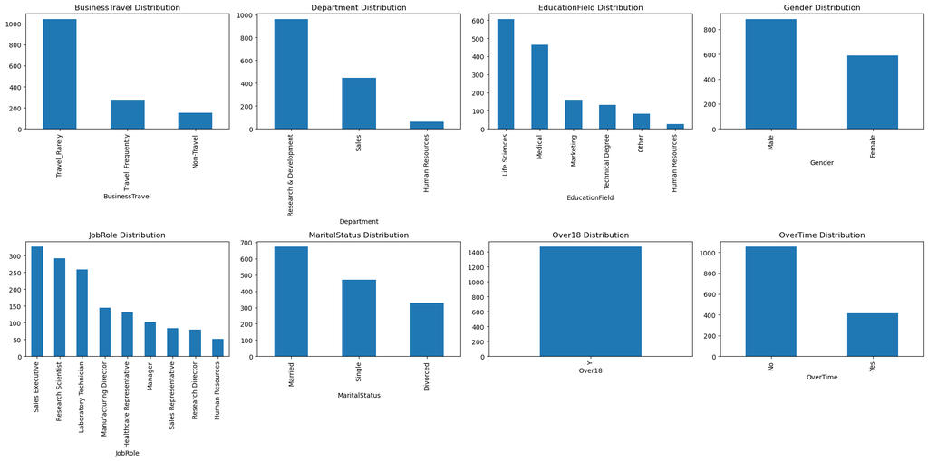

```python
categorical_cols = df.select_dtypes(include='object').columns.drop('Attrition')

fig, axes = plt.subplots(-(-len(categorical_cols)//4), 4, figsize=(20, 5 * -(-len(categorical_cols)//4)))
for ax, col in zip(axes.flatten(), categorical_cols):
    df[col].value_counts().plot.bar(ax=ax)
    ax.set_title(f'{col} Distribution')
for ax in axes.flatten()[len(categorical_cols):]:
    fig.delaxes(ax)
plt.tight_layout()
plt.show()
```

Variables with no variation are irrelevant for attrition analysis. Therefore, Over18 is not useful for this analysis.

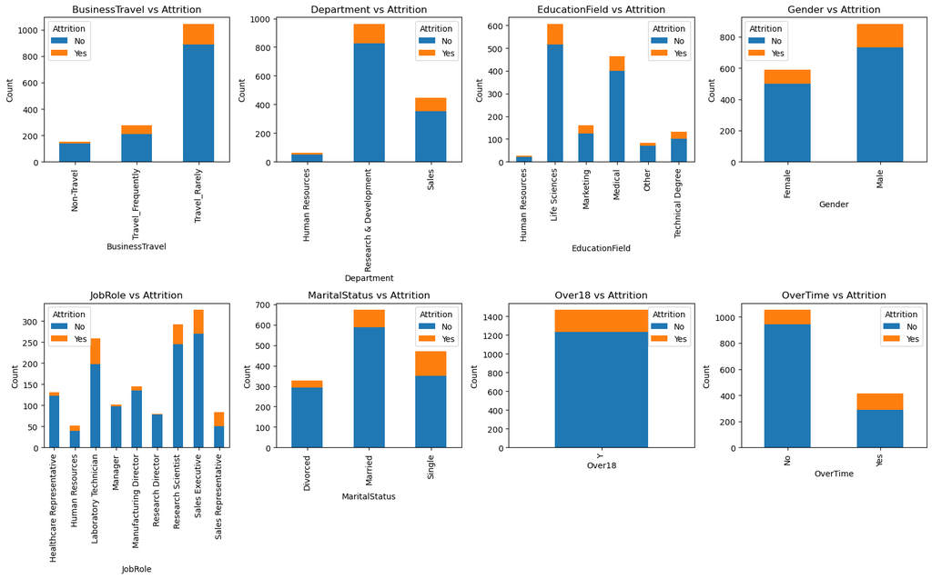

```python
num_cols = len(categorical_cols)
cols = 4
rows = (num_cols // cols) + int(num_cols % cols > 0)
fig, axes = plt.subplots(rows, cols, figsize=(cols*4, rows*5))
axes = axes.flatten()

for i, col in enumerate(categorical_cols):
    attrition_counts = pd.crosstab(df[col], df['Attrition'])
    attrition_counts.plot(kind='bar', stacked=True, ax=axes[i])
    axes[i].set_title(f'{col} vs Attrition')
    axes[i].set_ylabel('Count')

for j in range(i+1, len(axes)):
    axes[j].axis('off')

plt.tight_layout()
plt.show()
```

Stacked bars illustrate proportions

**Key Findings:**

- Frequent business travel is linked to higher attrition rates, suggesting that extensive travel demands may contribute to employee turnover.
- Sales department experiences higher turnover compared to other departments, indicating potential issues with job demands, satisfaction, or support.
- Job roles with high attrition include Sales Executives, Laboratory Technicians, and Sales Representatives, suggesting these roles may require additional support or resources.
- Single employees are more likely to leave, potentially due to fewer family commitments or greater job flexibility.
- Overtime work is strongly associated with higher attrition, implying that excessive work demands may lead to burnout and turnover.

**For ordinals:**

Ordinal features with Higher Value indication better condition.

- EnvironmentSatisfaction: (1-4) Higher is better
- JobInvolvement: (1-4) Ordinal, Importance Level
- JobSatisfaction: (1-4) Higher is better
- PerformanceRating: (1-4) Higher is better
- RelationshipSatisfaction: (1-4) Higher is better
- WorkLifeBalance: (1-4) Higher is better
- TrainingTimesLastYear: (0-6) Higher is better
- StockOptionLevel: (0-3) Higher is better

```python
ordinal_cols = ['EnvironmentSatisfaction', 'JobInvolvement','JobSatisfaction','PerformanceRating','RelationshipSatisfaction','WorkLifeBalance','TrainingTimesLastYear','StockOptionLevel']
```

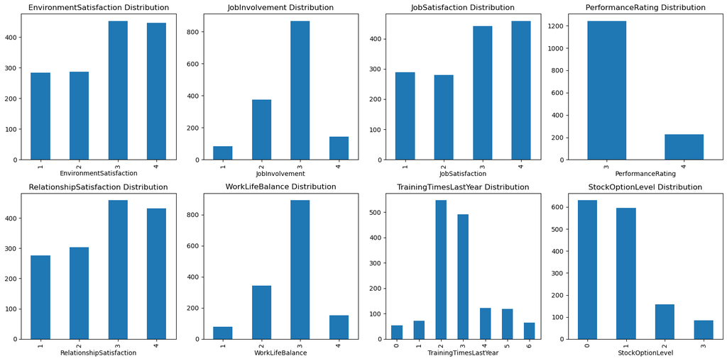

```python
num_cols = len(ordinal_cols)
cols = 4
rows = (num_cols // cols) + int(num_cols % cols > 0)
fig, axes = plt.subplots(rows, cols, figsize=(cols*4, rows*4))
axes = axes.flatten()

for i, col in enumerate(ordinal_cols):
    df[col].value_counts().sort_index().plot(kind='bar', ax=axes[i])
    axes[i].set_title(f'{col} Distribution')

for j in range(i+1, len(axes)):
    axes[j].axis('off')

plt.tight_layout()
plt.show()
```

Bars peak at higher levels (e.g., 3-4 for satisfactions), indicating generally positive ratings.

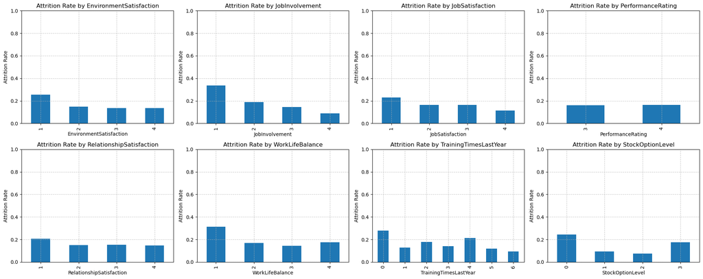

```python
num_cols = len(ordinal_cols)
cols = 4
rows = (num_cols // cols) + int(num_cols % cols > 0)
fig, axes = plt.subplots(rows, cols, figsize=(cols*5, rows*4))
axes = axes.flatten()

for i, col in enumerate(ordinal_cols):
    ctab = pd.crosstab(df[col], df['Attrition'], normalize='index')
    attrition_rate = ctab['Yes']
    attrition_rate.plot(kind='bar', ax=axes[i])
    axes[i].set_title(f'Attrition Rate by {col}')
    axes[i].set_ylabel('Attrition Rate')
    axes[i].set_ylim(0, 1)
    axes[i].grid(True, linestyle='--', alpha=0.7)

for j in range(i+1, len(axes)):
    fig.delaxes(axes[j])

plt.tight_layout()
plt.show()
```

This section highlights how categories like frequent travel and overtime, along with low satisfaction scores, are linked to higher attrition, offering straightforward interpretations for HR strategies.

## Section 5: Data Preprocessing

Preprocessing transforms raw data into a format suitable for machine learning, including scaling numerical features to prevent bias, encoding categories into numbers, and splitting data to evaluate model generalization. This step is vital because models require consistent, numerical input, and proper splitting avoids overfitting.

We define feature types, create transformers, and build a pipeline.

```python
from sklearn.model_selection import train_test_split
from sklearn.preprocessing import StandardScaler, OneHotEncoder
from sklearn.compose import ColumnTransformer
from sklearn.pipeline import Pipeline
from sklearn.impute import SimpleImputer
from sklearn.base import BaseEstimator, TransformerMixin

numerical_cols = [
    'Age', 'DailyRate', 'DistanceFromHome', 'Education', 'HourlyRate',
    'MonthlyIncome', 'MonthlyRate', 'NumCompaniesWorked', 'PercentSalaryHike',
    'TotalWorkingYears', 'TrainingTimesLastYear', 'YearsAtCompany',
    'YearsInCurrentRole', 'YearsSinceLastPromotion', 'YearsWithCurrManager'
]

ordinal_cols = [
    'EnvironmentSatisfaction', 'JobInvolvement', 'JobSatisfaction',
    'PerformanceRating', 'RelationshipSatisfaction', 'WorkLifeBalance',
    'TrainingTimesLastYear', 'StockOptionLevel'
]

categorical_cols = [
    'BusinessTravel', 'Department', 'EducationField', 'Gender', 'JobRole',
    'MaritalStatus', 'OverTime'
]

drop_cols = ['EmployeeNumber', 'EmployeeCount', 'StandardHours', 'Over18']

df['AttritionBinary'] = df['Attrition'].apply(lambda x: 1 if x == 'Yes' else 0)

numerical_transformer = Pipeline(steps=[
    ('imputer', SimpleImputer(strategy='median')),
    ('scaler', StandardScaler())
])

class PassThroughTransformer(BaseEstimator, TransformerMixin):
    def fit(self, X, y=None): return self
    def transform(self, X): return X

ordinal_transformer = PassThroughTransformer()

categorical_transformer = Pipeline(steps=[
    ('imputer', SimpleImputer(strategy='most_frequent')),
    ('onehot', OneHotEncoder(drop='first', handle_unknown='ignore'))
])

preprocessor = ColumnTransformer(
    transformers=[
        ('num', numerical_transformer, numerical_cols),
        ('ord', ordinal_transformer, ordinal_cols),
        ('cat', categorical_transformer, categorical_cols)
    ],
    remainder='drop'
)

preprocessor
```

```
ColumnTransformer(transformers=[('num',
                                 Pipeline(steps=[('imputer',
                                                  SimpleImputer(strategy='median')),
                                                 ('scaler', StandardScaler())]),
                                 ['Age', 'DailyRate', 'DistanceFromHome',
                                  'Education', 'HourlyRate', 'MonthlyIncome',
                                  'MonthlyRate', 'NumCompaniesWorked',
                                  'PercentSalaryHike', 'TotalWorkingYears',
                                  'TrainingTimesLastYear', 'YearsAtCompany',
                                  'YearsInCurrentRole',
                                  'Yea...
                                  'JobSatisfaction', 'PerformanceRating',
                                  'RelationshipSatisfaction', 'WorkLifeBalance',
                                  'TrainingTimesLastYear',
                                  'StockOptionLevel']),
                                ('cat',
                                 Pipeline(steps=[('imputer',
                                                  SimpleImputer(strategy='most_frequent')),
                                                 ('onehot',
                                                  OneHotEncoder(drop='first',
                                                                handle_unknown='ignore'))]),
                                 ['BusinessTravel', 'Department',
                                  'EducationField', 'Gender', 'JobRole',
                                  'MaritalStatus', 'OverTime'])])
```

The preprocessor output displays its structure, confirming the transformations for each feature type.

```python
X = df.drop(columns=drop_cols + ['Attrition', 'AttritionBinary'])
y = df['AttritionBinary']

X_train, X_test, y_train, y_test = train_test_split(X, y, test_size=0.2, random_state=42, stratify=y)
```

The split creates training (80%) and testing (20%) sets, with stratification preserving the 16% "Yes" ratio. This setup ensures the model learns from representative data and is evaluated fairly.

## Section 6: Model Training and Evaluation

We use Logistic Regression, a straightforward model that estimates probabilities of binary outcomes, making it ideal for beginners to understand feature impacts via coefficients. To address imbalance, we apply class weighting.

The pipeline integrates preprocessing and the model, and we evaluate using accuracy, precision, recall, F1-score, and confusion matrix for a comprehensive view.

```python
from sklearn.linear_model import LogisticRegression

logreg = LogisticRegression(random_state=42, class_weight='balanced', max_iter=1000)
logreg_pipeline = Pipeline([('preprocessor', preprocessor), ('classifier', logreg)])

logreg_pipeline.fit(X_train, y_train)
```

```
Pipeline(steps=[('preprocessor',
                 ColumnTransformer(transformers=[('num',
                                                  Pipeline(steps=[('imputer',
                                                                   SimpleImputer(strategy='median')),
                                                                  ('scaler',
                                                                   StandardScaler())]),
                                                  ['Age', 'DailyRate',
                                                   'DistanceFromHome',
                                                   'Education', 'HourlyRate',
                                                   'MonthlyIncome',
                                                   'MonthlyRate',
                                                   'NumCompaniesWorked',
                                                   'PercentSalaryHike',
                                                   'TotalWorkingYears',
                                                   'TrainingTimesLastYear',
                                                   'YearsAtCo...
                                                   'StockOptionLevel']),
                                                 ('cat',
                                                  Pipeline(steps=[('imputer',
                                                                   SimpleImputer(strategy='most_frequent')),
                                                                  ('onehot',
                                                                   OneHotEncoder(drop='first',
                                                                                 handle_unknown='ignore'))]),
                                                  ['BusinessTravel',
                                                   'Department',
                                                   'EducationField', 'Gender',
                                                   'JobRole', 'MaritalStatus',
                                                   'OverTime'])])),
                ('classifier',
                 LogisticRegression(class_weight='balanced', max_iter=1000,
                                    random_state=42))])
```

The fit trains the model on preprocessed training data.

```python
from sklearn.metrics import accuracy_score, confusion_matrix, classification_report

def print_score(clf, X_train, y_train, X_test, y_test, train=True):
    if train:
        pred = clf.predict(X_train)
        clf_report = pd.DataFrame(classification_report(y_train, pred, output_dict=True))
        print("Train Result:\n================================================")
        print(f"Accuracy Score: {accuracy_score(y_train, pred) * 100:.2f}%")
        print("_______________________________________________")
        print(f"CLASSIFICATION REPORT:\n{clf_report}")
        print("_______________________________________________")
        print(f"Confusion Matrix: \n {confusion_matrix(y_train, pred)}\n")

    else:
        pred = clf.predict(X_test)
        clf_report = pd.DataFrame(classification_report(y_test, pred, output_dict=True))
        print("Test Result:\n================================================")
        print(f"Accuracy Score: {accuracy_score(y_test, pred) * 100:.2f}%")
        print("_______________________________________________")
        print(f"CLASSIFICATION REPORT:\n{clf_report}")
        print("_______________________________________________")
        print(f"Confusion Matrix: \n {confusion_matrix(y_test, pred)}\n")

print_score(logreg_pipeline, X_train, y_train, X_test, y_test, train=False)
print_score(logreg_pipeline, X_train, y_train, X_test, y_test, train=True)
```

```
Test Result:
================================================
Accuracy Score: 76.19%
_______________________________________________
CLASSIFICATION REPORT:
                    0          1  accuracy   macro avg  weighted avg
precision    0.919431   0.361446  0.761905    0.640439      0.830230
recall       0.785425   0.638298  0.761905    0.711861      0.761905
f1-score     0.847162   0.461538  0.761905    0.654350      0.785514
support    247.000000  47.000000  0.761905  294.000000    294.000000
_______________________________________________
Confusion Matrix:
 [[194  53]
 [ 17  30]]

Train Result:
================================================
Accuracy Score: 77.98%
_______________________________________________
CLASSIFICATION REPORT:
                    0           1  accuracy    macro avg  weighted avg
precision    0.952677    0.407507  0.779762     0.680092      0.864597
recall       0.775862    0.800000  0.779762     0.787931      0.779762
f1-score     0.855226    0.539964  0.779762     0.697595      0.804291
support    986.000000  190.000000  0.779762  1176.000000   1176.000000
_______________________________________________
Confusion Matrix:
 [[765 221]
 [ 38 152]]
```

### Model Training and Evaluation

**Key Insight:** The model performs reasonably well but has room for improvement, particularly in precision for predicting attrition, suggesting potential for hyperparameter tuning or trying other algorithms (e.g., Random Forest, XGBoost) to handle imbalance better.

### Summary:

- The model performs well on class 0 (high precision and recall).
- It struggles more with class 1, especially in terms of precision.
- There's a slight drop in performance on the test set, particularly for class 1.
- Further improvement can be done through hyperparameter tuning

## Section 7: Hyperparameter Tuning

Tuning adjusts model settings to optimize performance, using GridSearchCV to test combinations and select the best based on F1-score for the minority class.

```python
from sklearn.metrics import f1_score, make_scorer
from sklearn.model_selection import GridSearchCV

logreg_pipeline = Pipeline([
    ('preprocessor', preprocessor),
    ('classifier', LogisticRegression(class_weight='balanced', random_state=42))
])

param_grid = {
    'classifier__C': [0.001, 0.01, 0.1, 1, 10, 100],
    'classifier__penalty': ['l1', 'l2'],
    'classifier__solver': ['liblinear']
}

scorer = make_scorer(f1_score, pos_label=1)

grid_search = GridSearchCV(
    estimator=logreg_pipeline,
    param_grid=param_grid,
    scoring=scorer,
    cv=5,
    n_jobs=-1,
    verbose=1
)

grid_search.fit(X_train, y_train)

print("Best Parameters:", grid_search.best_params_)
print("Best F1 Score:", grid_search.best_score_)

best_model = grid_search.best_estimator_
print_score(best_model, X_train, y_train, X_test, y_test, train=True)
print_score(best_model, X_train, y_train, X_test, y_test, train=False)
```

```
Fitting 5 folds for each of 12 candidates, totalling 60 fits
Best Parameters: {'classifier__C': 0.1, 'classifier__penalty': 'l2', 'classifier__solver': 'liblinear'}
Best F1 Score: 0.5107694499024578
Train Result:
================================================
Accuracy Score: 77.64%
_______________________________________________
CLASSIFICATION REPORT:
                    0           1  accuracy    macro avg  weighted avg
precision    0.947955    0.401084  0.776361     0.674520      0.859600
recall       0.775862    0.778947  0.776361     0.777405      0.776361
f1-score     0.853318    0.529517  0.776361     0.691418      0.801004
support    986.000000  190.000000  0.776361  1176.000000   1176.000000
_______________________________________________
Confusion Matrix:
 [[765 221]
 [ 42 148]]

Test Result:
================================================
Accuracy Score: 76.19%
_______________________________________________
CLASSIFICATION REPORT:
                    0          1  accuracy   macro avg  weighted avg
precision    0.927536   0.367816  0.761905    0.647676      0.838057
recall       0.777328   0.680851  0.761905    0.729089      0.761905
f1-score     0.845815   0.477612  0.761905    0.661713      0.786953
support    247.000000  47.000000  0.761905  294.000000    294.000000
_______________________________________________
Confusion Matrix:
 [[192  55]
 [ 15  32]]
```

**Hyperparameter Tuning:**

GridSearchCV evaluated 12 parameter combinations across 5 folds (60 fits), optimizing for F1-score. Best parameters: C=0.1, penalty='l2', solver='liblinear', achieving a best F1-score of 0.511.

**Test Performance:** The best model yields 76.19% accuracy on the test set, with precision/recall for Attrition=Yes at 0.368/0.681, indicating decent recall but low precision due to 55 false positives.

**Train Performance:** Training accuracy is 77.64%, with precision/recall for Attrition=Yes at 0.401/0.779, showing high recall but persistent low precision (221 false positives).

**Confusion Matrix:** Test set shows 192 true negatives, 32 true positives, 55 false positives, and 15 false negatives, confirming challenges in precise identification of attrition cases.

**Model Limitation:** Despite tuning, precision for the minority class remains low, suggesting the model over-predicts attrition, likely due to class imbalance (16% attrition rate).

**Improvement Potential:** The slight drop in test performance (F1-score: 0.478 vs. 0.530 on training) indicates possible overfitting; alternative models like Random Forest or SMOTE could improve results.

## Section 8: Feature Importance

Feature importance in logistic regression comes from coefficients, where positive values increase attrition odds and negative decrease them. Odds ratios (exp(coefficient)) make this interpretable, e.g., >1 means higher risk.

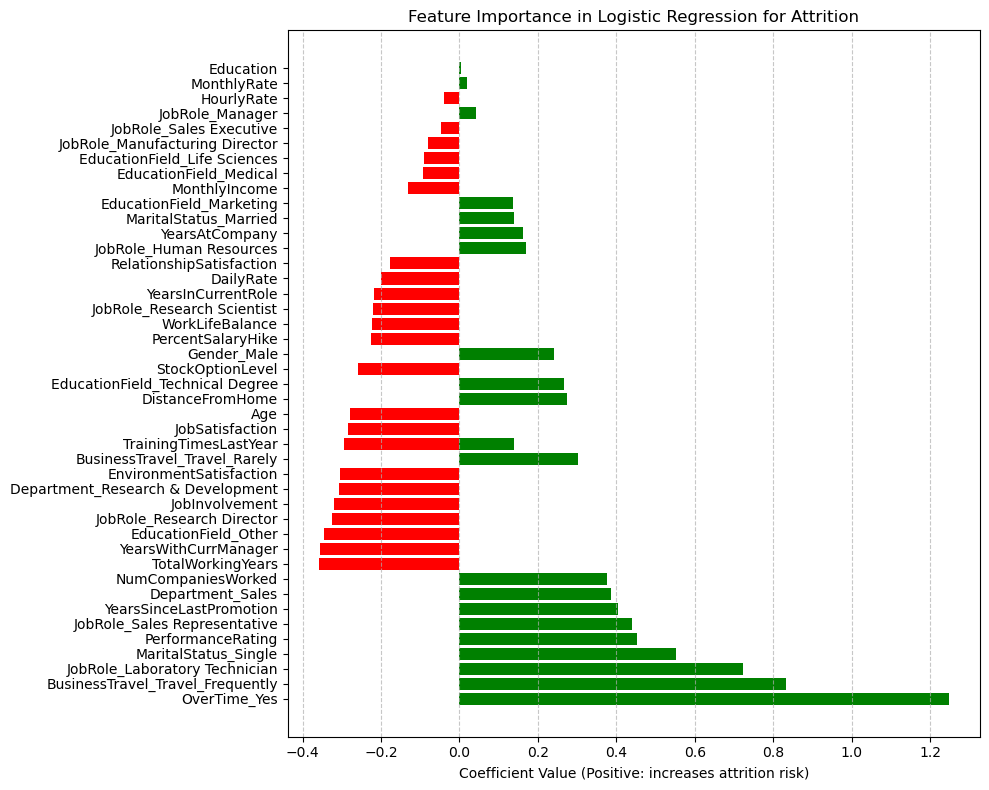

```python
import numpy as np

def get_feature_names_from_column_transformer(column_transformer):
    feature_names = []
    for name, transformer, columns in column_transformer.transformers_:
        if name != 'remainder':
            if hasattr(transformer, 'get_feature_names_out'):
                names = transformer.get_feature_names_out(columns)
            elif hasattr(transformer, 'get_feature_names'):
                names = transformer.get_feature_names(columns)
            else:
                names = columns
            feature_names.extend(names)
    return feature_names

feature_names = get_feature_names_from_column_transformer(preprocessor)

coefs = best_model.named_steps['classifier'].coef_[0]

importance_df = pd.DataFrame({
    'Feature': feature_names,
    'Coefficient': coefs
})

importance_df = importance_df.reindex(importance_df['Coefficient'].abs().sort_values(ascending=False).index)

plt.figure(figsize=(10,8))
colors = np.where(importance_df['Coefficient'] > 0, 'green', 'red')
plt.barh(importance_df['Feature'], importance_df['Coefficient'], color=colors)
plt.xlabel('Coefficient Value (Positive: increases attrition risk)')
plt.title('Feature Importance in Logistic Regression for Attrition')
plt.grid(axis='x', linestyle='--', alpha=0.7)
plt.tight_layout()
plt.show()
```

**Interpretation:**

### Odds Ratio Table

```python
coefs = best_model.named_steps['classifier'].coef_[0]
odds_ratios_df = pd.DataFrame({
    'Feature': feature_names,
    'Coefficient': coefs,
    'Odds Ratio': np.exp(coefs)
})

odds_ratios_df['Effect Strength'] = np.abs(odds_ratios_df['Odds Ratio'])
odds_ratios_df = odds_ratios_df.sort_values(by='Effect Strength', ascending=False)

print(odds_ratios_df[['Feature', 'Coefficient', 'Odds Ratio']])
```

```
                              Feature  Coefficient  Odds Ratio
43                       OverTime_Yes     1.246606    3.478517
23   BusinessTravel_Travel_Frequently     0.833301    2.300901
34      JobRole_Laboratory Technician     0.723325    2.061276
42               MaritalStatus_Single     0.552825    1.738156
18                  PerformanceRating     0.452551    1.572319
40       JobRole_Sales Representative     0.440687    1.553774
13            YearsSinceLastPromotion     0.404419    1.498432
26                   Department_Sales     0.385716    1.470667
7                  NumCompaniesWorked     0.375276    1.455393
24       BusinessTravel_Travel_Rarely     0.301631    1.352063
2                    DistanceFromHome     0.274822    1.316296
31    EducationField_Technical Degree     0.266230    1.305035
32                        Gender_Male     0.241369    1.272991
33            JobRole_Human Resources     0.169227    1.184389
```

[output cut: 30 more lines]

**Understanding the Table:**

The table shows the relationship between various features and employee attrition, with two key metrics:

- Coefficient: Measures the change in log odds of attrition.
- Odds Ratio: Represents the multiplier effect on attrition odds.

**Key Insights:**

- OverTime_Yes has an odds ratio of 3.48, meaning working overtime increases the likelihood of attrition by 248% (3.48 times).
- BusinessTravel_Travel_Frequently has an odds ratio of 2.30, indicating frequent travel increases attrition risk by 130%.
- Features with odds ratios > 1 increase attrition risk, while those < 1 decrease it.
- TotalWorkingYears has an odds ratio of 0.70, suggesting more experienced employees are less likely to leave.

**Actionable Recommendations:**

- Reduce overtime: Implement strategies to manage workload and prevent excessive overtime.
- Optimize business travel: Review travel policies and provide support for frequent travelers.
- Focus on job roles and departments: Address specific pain points in high-attrition roles (e.g., Sales Representatives) and departments (e.g., Sales).

By targeting these areas, organizations can reduce attrition and improve employee retention.